# Twitter US Airlines Sentiment Analysis

#### 1. Import the libraries, load dataset, print shape of data, data description

```python
# Pip Install

!pip install contractions
```

```python
# Install and Import necessary libraries.

import re, string, unicodedata                          # Import Regex, string and unicodedata
import contractions                                     # Import contractions
from bs4 import BeautifulSoup                           # Import BeautifulSoup

import numpy as np                                      # Import numpy
import pandas as pd                                     # Import pandas
import nltk                                             # Import Natural Language Tool-Kit
import matplotlib.pyplot as plt                         # Import matplotlib
import seaborn as sns                                   # Import seaborn


nltk.download('stopwords')                              # Download Stopwords.
nltk.download('punkt')
nltk.download('wordnet')

from nltk.corpus import stopwords                       # Import stopwords.
from nltk.tokenize import word_tokenize, sent_tokenize  # Import Tokenizer.
from nltk.stem.wordnet import WordNetLemmatizer         # Import Lemmatizer.

# Import classification algorithms and related metrics
from sklearn.feature_extraction.text import CountVectorizer, TfidfVectorizer
from sklearn.model_selection import train_test_split, cross_val_score
from sklearn.ensemble import RandomForestClassifier
from sklearn.metrics import confusion_matrix
```

```python
# Loading data into pandas dataframe
tweets = pd.read_csv("Tweets.csv")
```

```python
tweets.shape                                               # print shape of data.
```

```
(14640, 15)
```

```python
tweets.head()                                              # Print first 5 rows of data.
```

|  | tweet_id | airline_sentiment | airline_sentiment_confidence | negativereason | negativereason_confidence | airline | airline_sentiment_gold | name | negativereason_gold | retweet_count | text | tweet_coord | tweet_created | tweet_location | user_timezone |
| --- | --- | --- | --- | --- | --- | --- | --- | --- | --- | --- | --- | --- | --- | --- | --- |
| 0 | 570306133677760513 | neutral | 1.0000 | NaN | NaN | Virgin America | NaN | cairdin | NaN | 0 | @VirginAmerica What @dhepburn said. | NaN | 2015-02-24 11:35:52 -0800 | NaN | Eastern Time (US & Canada) |
| 1 | 570301130888122368 | positive | 0.3486 | NaN | 0.0000 | Virgin America | NaN | jnardino | NaN | 0 | @VirginAmerica plus you've added commercials t... | NaN | 2015-02-24 11:15:59 -0800 | NaN | Pacific Time (US & Canada) |
| 2 | 570301083672813571 | neutral | 0.6837 | NaN | NaN | Virgin America | NaN | yvonnalynn | NaN | 0 | @VirginAmerica I didn't today... Must mean I n... | NaN | 2015-02-24 11:15:48 -0800 | Lets Play | Central Time (US & Canada) |
| 3 | 570301031407624196 | negative | 1.0000 | Bad Flight | 0.7033 | Virgin America | NaN | jnardino | NaN | 0 | @VirginAmerica it's really aggressive to blast... | NaN | 2015-02-24 11:15:36 -0800 | NaN | Pacific Time (US & Canada) |
| 4 | 570300817074462722 | negative | 1.0000 | Can't Tell | 1.0000 | Virgin America | NaN | jnardino | NaN | 0 | @VirginAmerica and it's a really big bad thing... | NaN | 2015-02-24 11:14:45 -0800 | NaN | Pacific Time (US & Canada) |

```python
tweets.isnull().sum(axis=0)                                # Check for NULL values.
```

```
tweet_id                            0
airline_sentiment                   0
airline_sentiment_confidence        0
negativereason                   5462
negativereason_confidence        4118
airline                             0
airline_sentiment_gold          14600
name                                0
negativereason_gold             14608
retweet_count                       0
text                                0
tweet_coord                     13621
tweet_created                       0
tweet_location                   4733
user_timezone                    4820
dtype: int64
```

```python
pd.set_option('display.max_colwidth', None) # Display full dataframe information (Non-turncated Text column.)

tweets.head()                                 # Check first 5 rows of data
```

|  | tweet_id | airline_sentiment | airline_sentiment_confidence | negativereason | negativereason_confidence | airline | airline_sentiment_gold | name | negativereason_gold | retweet_count | text | tweet_coord | tweet_created | tweet_location | user_timezone |
| --- | --- | --- | --- | --- | --- | --- | --- | --- | --- | --- | --- | --- | --- | --- | --- |
| 0 | 570306133677760513 | neutral | 1.0000 | NaN | NaN | Virgin America | NaN | cairdin | NaN | 0 | @VirginAmerica What @dhepburn said. | NaN | 2015-02-24 11:35:52 -0800 | NaN | Eastern Time (US & Canada) |
| 1 | 570301130888122368 | positive | 0.3486 | NaN | 0.0000 | Virgin America | NaN | jnardino | NaN | 0 | @VirginAmerica plus you've added commercials to the experience... tacky. | NaN | 2015-02-24 11:15:59 -0800 | NaN | Pacific Time (US & Canada) |
| 2 | 570301083672813571 | neutral | 0.6837 | NaN | NaN | Virgin America | NaN | yvonnalynn | NaN | 0 | @VirginAmerica I didn't today... Must mean I need to take another trip! | NaN | 2015-02-24 11:15:48 -0800 | Lets Play | Central Time (US & Canada) |
| 3 | 570301031407624196 | negative | 1.0000 | Bad Flight | 0.7033 | Virgin America | NaN | jnardino | NaN | 0 | @VirginAmerica it's really aggressive to blast obnoxious "entertainment" in your guests' faces &amp; they have little recourse | NaN | 2015-02-24 11:15:36 -0800 | NaN | Pacific Time (US & Canada) |
| 4 | 570300817074462722 | negative | 1.0000 | Can't Tell | 1.0000 | Virgin America | NaN | jnardino | NaN | 0 | @VirginAmerica and it's a really big bad thing about it | NaN | 2015-02-24 11:14:45 -0800 | NaN | Pacific Time (US & Canada) |

```python
tweets.describe()                             # Displays metrics info for the numerical features
```

|  | tweet_id | airline_sentiment_confidence | negativereason_confidence | retweet_count |
| --- | --- | --- | --- | --- |
| count | 1.464000e+04 | 14640.000000 | 10522.000000 | 14640.000000 |
| mean | 5.692184e+17 | 0.900169 | 0.638298 | 0.082650 |
| std | 7.791112e+14 | 0.162830 | 0.330440 | 0.745778 |
| min | 5.675883e+17 | 0.335000 | 0.000000 | 0.000000 |
| 25% | 5.685592e+17 | 0.692300 | 0.360600 | 0.000000 |
| 50% | 5.694779e+17 | 1.000000 | 0.670600 | 0.000000 |
| 75% | 5.698905e+17 | 1.000000 | 1.000000 | 0.000000 |
| max | 5.703106e+17 | 1.000000 | 1.000000 | 44.000000 |

```python
# Total number of words in the 'Text' column
print(tweets['text'].apply(lambda x: len(x.split(' '))).sum())
```

```
260526
```

##### Insights:

- The dataset has 14640 records with 15 features
- The total number of text/tweets to be reviewed is 260,526 words
- Sentiments can be classified into 3 classes - Positive, Negative and Neutral
- When the tweet is not negative, the features corresponding to negative reason will be null
- Our classification should focus on the content of the tweet and what sentiment it implies, hence all the other features have no bearing on the dependent variable and can be dropped

#### 2. Understanding data-columns:

- a. Drop all columns except "text" and "airline_sentiment"
- b. Check the shape of data
- c. Print first 5 rows of data

```python
tweets.shape                                # Shape of data
```

```
(14640, 15)
```

```python
tweets.head()
```

|  | tweet_id | airline_sentiment | airline_sentiment_confidence | negativereason | negativereason_confidence | airline | airline_sentiment_gold | name | negativereason_gold | retweet_count | text | tweet_coord | tweet_created | tweet_location | user_timezone |
| --- | --- | --- | --- | --- | --- | --- | --- | --- | --- | --- | --- | --- | --- | --- | --- |
| 0 | 570306133677760513 | neutral | 1.0000 | NaN | NaN | Virgin America | NaN | cairdin | NaN | 0 | @VirginAmerica What @dhepburn said. | NaN | 2015-02-24 11:35:52 -0800 | NaN | Eastern Time (US & Canada) |
| 1 | 570301130888122368 | positive | 0.3486 | NaN | 0.0000 | Virgin America | NaN | jnardino | NaN | 0 | @VirginAmerica plus you've added commercials to the experience... tacky. | NaN | 2015-02-24 11:15:59 -0800 | NaN | Pacific Time (US & Canada) |
| 2 | 570301083672813571 | neutral | 0.6837 | NaN | NaN | Virgin America | NaN | yvonnalynn | NaN | 0 | @VirginAmerica I didn't today... Must mean I need to take another trip! | NaN | 2015-02-24 11:15:48 -0800 | Lets Play | Central Time (US & Canada) |
| 3 | 570301031407624196 | negative | 1.0000 | Bad Flight | 0.7033 | Virgin America | NaN | jnardino | NaN | 0 | @VirginAmerica it's really aggressive to blast obnoxious "entertainment" in your guests' faces &amp; they have little recourse | NaN | 2015-02-24 11:15:36 -0800 | NaN | Pacific Time (US & Canada) |
| 4 | 570300817074462722 | negative | 1.0000 | Can't Tell | 1.0000 | Virgin America | NaN | jnardino | NaN | 0 | @VirginAmerica and it's a really big bad thing about it | NaN | 2015-02-24 11:14:45 -0800 | NaN | Pacific Time (US & Canada) |

#### Data analysis

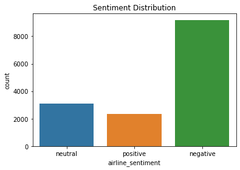

```python
sns.countplot(x=tweets["airline_sentiment"])
plt.title("Sentiment Distribution")
plt.show()
```

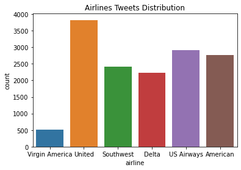

```python
sns.countplot(x=tweets["airline"])
plt.title("Airlines Tweets Distribution")
plt.show()
```

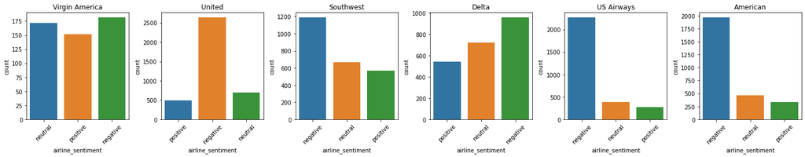

```python
j=1
plt.subplots(figsize=(20,4),tight_layout=True)
for i in tweets["airline"].unique():
        x = tweets[tweets["airline"]==i]
        plt.subplot(1, 6, j)
        sns.countplot(x["airline_sentiment"])
        plt.xticks(rotation=45)
        plt.title(i)
        j +=1
plt.show()
```

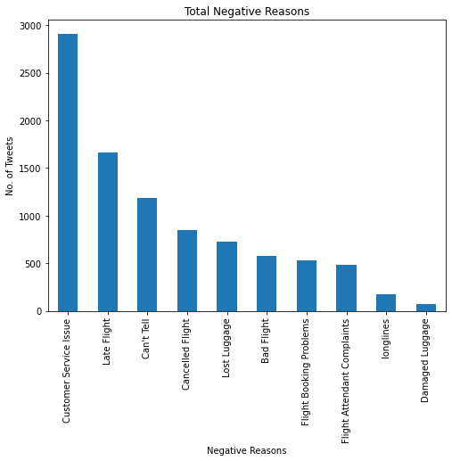

```python
#Plotting all the negative reasons

pd.Series(tweets["negativereason"]).value_counts().plot(kind = "bar",
                        figsize=(8,6),title = "Total Negative Reasons")
plt.xlabel('Negative Reasons', fontsize=10)
plt.ylabel('No. of Tweets', fontsize=10)
```

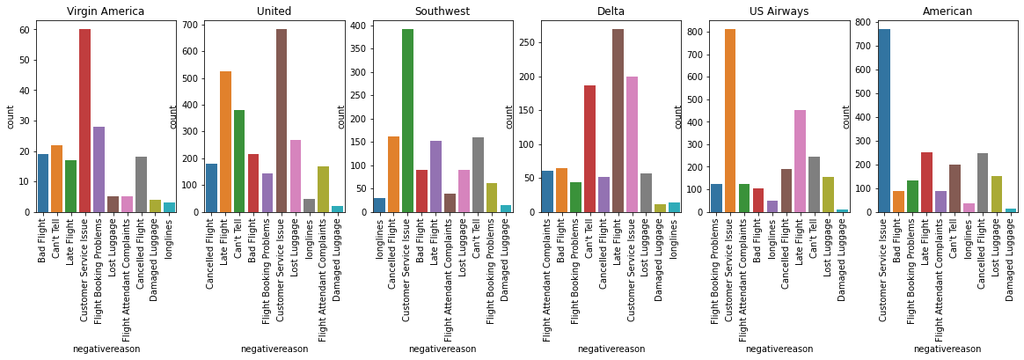

```python
j=1
plt.subplots(figsize=(20,4))
for i in tweets["airline"].unique():
        x = tweets[tweets["airline"]==i]
        plt.subplot(1, 6, j)
        sns.countplot(x["negativereason"])
        plt.xticks(rotation=90)
        plt.title(i)
        j +=1
plt.show()
```

```python
# Only keeping Airline_sentiment and Text columns from the data, as these are useful for our analysis.

tweets = tweets.loc[:, ['airline_sentiment', 'text']]
```

```python
tweets.shape
```

```
(14640, 2)
```

```python
tweets.head()
```

|  | airline_sentiment | text |
| --- | --- | --- |
| 0 | neutral | @VirginAmerica What @dhepburn said. |
| 1 | positive | @VirginAmerica plus you've added commercials to the experience... tacky. |
| 2 | neutral | @VirginAmerica I didn't today... Must mean I need to take another trip! |
| 3 | negative | @VirginAmerica it's really aggressive to blast obnoxious "entertainment" in your guests' faces &amp; they have little recourse |
| 4 | negative | @VirginAmerica and it's a really big bad thing about it |

#### 3. Text Pre-processing: Data preparation

- a. Remove html tags
- b. Tokenization
- c. Remove numbers
- d. Remove Special characters and punctuation
- e. Convert to lowercase
- f. Lemmatize or Stemming
- g. Join the words in the list to convert back to text string in the dataframe
- h. Print first 5 rows after pre-processing

We have used NLTK library to tokenize words , remove stopwords and lemmatize the remaining words.

```python
def strip_html(text):
    soup = BeautifulSoup(text, "html.parser")
    return soup.get_text()

tweets['text'] = tweets['text'].apply(lambda x: strip_html(x))
tweets.head()
```

|  | airline_sentiment | text |
| --- | --- | --- |
| 0 | neutral | @VirginAmerica What @dhepburn said. |
| 1 | positive | @VirginAmerica plus you've added commercials to the experience... tacky. |
| 2 | neutral | @VirginAmerica I didn't today... Must mean I need to take another trip! |
| 3 | negative | @VirginAmerica it's really aggressive to blast obnoxious "entertainment" in your guests' faces & they have little recourse |
| 4 | negative | @VirginAmerica and it's a really big bad thing about it |

```python
def replace_contractions(text):
    """Replace contractions in string of text"""
    return contractions.fix(text)

tweets['text'] = tweets['text'].apply(lambda x: replace_contractions(x))
tweets.head()

## Note how 'you've' has changed to 'you have' in second row and 'didn't' changed to 'did not'
## in third row
```

|  | airline_sentiment | text |
| --- | --- | --- |
| 0 | neutral | @VirginAmerica What @dhepburn said. |
| 1 | positive | @VirginAmerica plus you have added commercials to the experience... tacky. |
| 2 | neutral | @VirginAmerica I did not today... Must mean I need to take another trip! |
| 3 | negative | @VirginAmerica it is really aggressive to blast obnoxious "entertainment" in your guests' faces & they have little recourse |
| 4 | negative | @VirginAmerica and it is a really big bad thing about it |

```python
def remove_numbers(text):
  text = re.sub(r'\d+', '', text)
  return text

tweets['text'] = tweets['text'].apply(lambda x: remove_numbers(x))
tweets.head()
```

|  | airline_sentiment | text |
| --- | --- | --- |
| 0 | neutral | @VirginAmerica What @dhepburn said. |
| 1 | positive | @VirginAmerica plus you have added commercials to the experience... tacky. |
| 2 | neutral | @VirginAmerica I did not today... Must mean I need to take another trip! |
| 3 | negative | @VirginAmerica it is really aggressive to blast obnoxious "entertainment" in your guests' faces & they have little recourse |
| 4 | negative | @VirginAmerica and it is a really big bad thing about it |

```python
tweets['text'] = tweets.apply(lambda row: nltk.word_tokenize(row['text']), axis=1) # Tokenization of data
tweets.head()
```

|  | airline_sentiment | text |
| --- | --- | --- |
| 0 | neutral | [@, VirginAmerica, What, @, dhepburn, said, .] |
| 1 | positive | [@, VirginAmerica, plus, you, have, added, commercials, to, the, experience, ..., tacky, .] |
| 2 | neutral | [@, VirginAmerica, I, did, not, today, ..., Must, mean, I, need, to, take, another, trip, !] |
| 3 | negative | [@, VirginAmerica, it, is, really, aggressive, to, blast, obnoxious, ``, entertainment, '', in, your, guests, ', faces, &, they, have, little, recourse] |
| 4 | negative | [@, VirginAmerica, and, it, is, a, really, big, bad, thing, about, it] |

```python
stopwords = stopwords.words('english')

# Setting the 'not' words as exclusion list since these words matter for sentiment analysis
exclude = ['not', "couldn't", 'didn', "didn't", 'doesn', "doesn't", 'hadn', "hadn't", 'hasn',
        "hasn't", 'haven', "haven't", 'isn', "isn't", 'ma', 'mightn', "mightn't", 'mustn',
        "mustn't", 'needn', "needn't", 'shan', "shan't", 'shouldn', "shouldn't", 'wasn',
        "wasn't", 'weren', "weren't", 'won', "won't", 'wouldn', "wouldn't"]


stopwords = list(set(stopwords) - set(exclude))
```

```python
lemmatizer = WordNetLemmatizer()

def remove_non_ascii(words):
    """Remove non-ASCII characters from list of tokenized words"""
    new_words = []
    for word in words:
        new_word = unicodedata.normalize('NFKD', word).encode('ascii', 'ignore').decode('utf-8', 'ignore')
        new_words.append(new_word)
    return new_words

def to_lowercase(words):
    """Convert all characters to lowercase from list of tokenized words"""
    new_words = []
    for word in words:
        new_word = word.lower()
        new_words.append(new_word)
    return new_words

def remove_punctuation(words):
    """Remove punctuation from list of tokenized words"""
    new_words = []
    for word in words:
        new_word = re.sub(r'[^\w\s]', '', word)
        if new_word != '':
            new_words.append(new_word)
    return new_words

def remove_stopwords(words):
    """Remove stop words from list of tokenized words"""
    new_words = []
    for word in words:
        if word not in stopwords:
            new_words.append(word)
    return new_words

def lemmatize_list(words):
    new_words = []
    for word in words:
      new_words.append(lemmatizer.lemmatize(word, pos='v'))
    return new_words

def normalize(words):
    words = remove_non_ascii(words)
    words = to_lowercase(words)
    words = remove_punctuation(words)
    words = remove_stopwords(words)
    words = lemmatize_list(words)
    return ' '.join(words)

tweets['text'] = tweets.apply(lambda row: normalize(row['text']), axis=1)
tweets.head()
```

|  | airline_sentiment | text |
| --- | --- | --- |
| 0 | neutral | virginamerica dhepburn say |
| 1 | positive | virginamerica plus add commercials experience tacky |
| 2 | neutral | virginamerica not today must mean need take another trip |
| 3 | negative | virginamerica really aggressive blast obnoxious entertainment guests face little recourse |
| 4 | negative | virginamerica really big bad thing |

```python
# Total number of words in the 'Text' column
print('Total number of words after pre-processing:',tweets['text'].apply(lambda x: len(x.split(' '))).sum())
```

```
Total number of words after pre-processing: 147547
```

#### 4. Vectorization:

- a.Use CountVectorizer
- b.Use TfidfVectorizer

```python
# Convert Sentiments values to numbers
from sklearn.preprocessing import LabelEncoder
encoder = LabelEncoder()
tweets["airline_sentiment"] = encoder.fit_transform(tweets["airline_sentiment"])
print(encoder.classes_)
tweets.head()
```

```
['negative' 'neutral' 'positive']
```

|  | airline_sentiment | text |
| --- | --- | --- |
| 0 | 1 | virginamerica dhepburn say |
| 1 | 2 | virginamerica plus add commercials experience tacky |
| 2 | 1 | virginamerica not today must mean need take another trip |
| 3 | 0 | virginamerica really aggressive blast obnoxious entertainment guests face little recourse |
| 4 | 0 | virginamerica really big bad thing |

```python
# Vectorization using COUNTVECTORIZER
from sklearn.feature_extraction.text import CountVectorizer

vectorizer = CountVectorizer(max_features=1000)  # Keep only 1000 features as number of features will increase the processing time.
# Tried keeping max_features at 5000 and didn't see any difference in score
tweets_features = vectorizer.fit_transform(tweets['text'])

tweets_features = tweets_features.toarray()                 # Convert the data features to array
tweets_features_df = pd.DataFrame(data = tweets_features ,
                                columns = vectorizer.get_feature_names())
tweets_features_df.head()
```

|  | aa | able | absolute | absolutely | accept | acceptable | access | accommodate | account | act | ... | yeah | year | years | yep | yes | yesterday | yet | yo | yr | zero |
| --- | --- | --- | --- | --- | --- | --- | --- | --- | --- | --- | --- | --- | --- | --- | --- | --- | --- | --- | --- | --- | --- |
| 0 | 0 | 0 | 0 | 0 | 0 | 0 | 0 | 0 | 0 | 0 | ... | 0 | 0 | 0 | 0 | 0 | 0 | 0 | 0 | 0 | 0 |
| 1 | 0 | 0 | 0 | 0 | 0 | 0 | 0 | 0 | 0 | 0 | ... | 0 | 0 | 0 | 0 | 0 | 0 | 0 | 0 | 0 | 0 |
| 2 | 0 | 0 | 0 | 0 | 0 | 0 | 0 | 0 | 0 | 0 | ... | 0 | 0 | 0 | 0 | 0 | 0 | 0 | 0 | 0 | 0 |
| 3 | 0 | 0 | 0 | 0 | 0 | 0 | 0 | 0 | 0 | 0 | ... | 0 | 0 | 0 | 0 | 0 | 0 | 0 | 0 | 0 | 0 |
| 4 | 0 | 0 | 0 | 0 | 0 | 0 | 0 | 0 | 0 | 0 | ... | 0 | 0 | 0 | 0 | 0 | 0 | 0 | 0 | 0 | 0 |

5 rows × 1000 columns

```python
tweets_features.shape
```

```
(14640, 1000)
```

```python
labels = tweets['airline_sentiment']
labels = labels.astype('int')
```

```python
# Split data into training and testing set.

from sklearn.model_selection import train_test_split

X_train, X_test, y_train, y_test = train_test_split(tweets_features_df, labels, test_size=0.3, random_state=42)
```

```python
# Using Random Forest to build model for the classification of reviews.
# Also calculating the cross validation score.

from sklearn.model_selection import cross_val_score

forest = RandomForestClassifier(n_estimators=10, n_jobs=4)

forest = forest.fit(X_train, y_train)

print(forest)

print(np.mean(cross_val_score(forest, tweets_features_df, labels, cv=10)))
```

```
RandomForestClassifier(n_estimators=10, n_jobs=4)
0.7088114754098361
```

```python
# Predict the result for test data using the model built above.

result = forest.predict(X_test)
```

```
[[2499  223   92]
 [ 354  440   90]
 [ 173  120  401]]
```

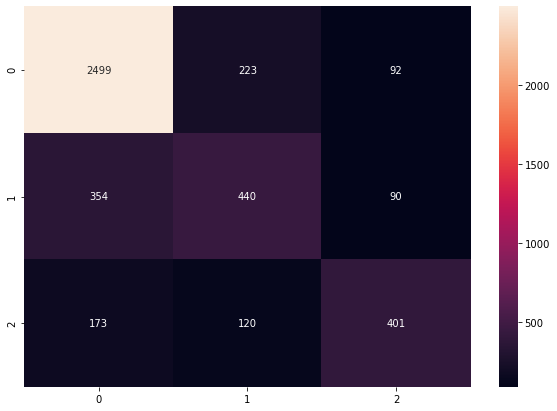

```python
# Print and plot Confusion matirx to get an idea of how the distribution of the prediction is, among all the classes.

conf_mat = confusion_matrix(y_test, result)

print(conf_mat)

df_cm = pd.DataFrame(conf_mat, index = [i for i in "012"],
                  columns = [i for i in "012"])
plt.figure(figsize = (10,7))
sns.heatmap(df_cm, annot=True, fmt='g')
```

```python
from sklearn.metrics import classification_report,accuracy_score
print('accuracy %', accuracy_score(result,y_test))
print(classification_report(y_test, result))
```

```
accuracy % 0.7604735883424408
              precision    recall  f1-score   support

           0       0.83      0.89      0.86      2814
           1       0.56      0.50      0.53       884
           2       0.69      0.58      0.63       694

    accuracy                           0.76      4392
   macro avg       0.69      0.65      0.67      4392
weighted avg       0.75      0.76      0.75      4392
```

```python
# Vectorization using TFIDFVECTORIZER

from sklearn.feature_extraction.text import TfidfVectorizer

vectorizer = TfidfVectorizer(max_features=1000)
tweets_features = vectorizer.fit_transform(tweets['text'])

tweets_features = tweets_features.toarray()
tweets_features_df = pd.DataFrame(data = tweets_features ,
                                columns = vectorizer.get_feature_names())
tweets_features_df.head()
```

|  | aa | able | absolute | absolutely | accept | acceptable | access | accommodate | account | act | ... | yeah | year | years | yep | yes | yesterday | yet | yo | yr | zero |
| --- | --- | --- | --- | --- | --- | --- | --- | --- | --- | --- | --- | --- | --- | --- | --- | --- | --- | --- | --- | --- | --- |
| 0 | 0.0 | 0.0 | 0.0 | 0.0 | 0.0 | 0.0 | 0.0 | 0.0 | 0.0 | 0.0 | ... | 0.0 | 0.0 | 0.0 | 0.0 | 0.0 | 0.0 | 0.0 | 0.0 | 0.0 | 0.0 |
| 1 | 0.0 | 0.0 | 0.0 | 0.0 | 0.0 | 0.0 | 0.0 | 0.0 | 0.0 | 0.0 | ... | 0.0 | 0.0 | 0.0 | 0.0 | 0.0 | 0.0 | 0.0 | 0.0 | 0.0 | 0.0 |
| 2 | 0.0 | 0.0 | 0.0 | 0.0 | 0.0 | 0.0 | 0.0 | 0.0 | 0.0 | 0.0 | ... | 0.0 | 0.0 | 0.0 | 0.0 | 0.0 | 0.0 | 0.0 | 0.0 | 0.0 | 0.0 |
| 3 | 0.0 | 0.0 | 0.0 | 0.0 | 0.0 | 0.0 | 0.0 | 0.0 | 0.0 | 0.0 | ... | 0.0 | 0.0 | 0.0 | 0.0 | 0.0 | 0.0 | 0.0 | 0.0 | 0.0 | 0.0 |
| 4 | 0.0 | 0.0 | 0.0 | 0.0 | 0.0 | 0.0 | 0.0 | 0.0 | 0.0 | 0.0 | ... | 0.0 | 0.0 | 0.0 | 0.0 | 0.0 | 0.0 | 0.0 | 0.0 | 0.0 | 0.0 |

5 rows × 1000 columns

```python
tweets_features_df.shape
```

```
(14640, 1000)
```

```python
# Using Random Forest to build model for the classification of reviews.
# Also calculating the cross validation score.

forest = RandomForestClassifier(n_estimators=10, n_jobs=4)

forest = forest.fit(X_train, y_train)

print(forest)

print(np.mean(cross_val_score(forest, tweets_features_df, labels, cv=10)))
```

```
RandomForestClassifier(n_estimators=10, n_jobs=4)
0.7131147540983607
```

```python
result = forest.predict(X_test)
```

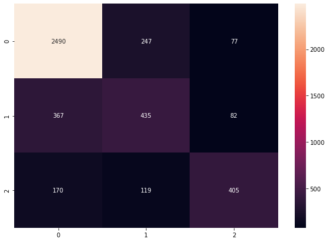

```python
conf_mat = confusion_matrix(y_test, result)

df_cm = pd.DataFrame(conf_mat, index = [i for i in "012"],
                  columns = [i for i in "012"])
plt.figure(figsize = (10,7))
sns.heatmap(df_cm, annot=True, fmt='g')
```

```python
from sklearn.metrics import classification_report,accuracy_score
print('accuracy %', accuracy_score(result,y_test))
print(classification_report(y_test, result))
```

```
accuracy % 0.7581967213114754
              precision    recall  f1-score   support

           0       0.82      0.88      0.85      2814
           1       0.54      0.49      0.52       884
           2       0.72      0.58      0.64       694

    accuracy                           0.76      4392
   macro avg       0.69      0.65      0.67      4392
weighted avg       0.75      0.76      0.75      4392
```

##### Insights/Summary:

- The base data is airline reviews tweeted by customers
- The dataset used has reviews in text format and the sentiment was classified as positive, negative and neutral
- The goal was to build a model for text-classification.
- The dataset was fairly skewed towards more negative reviews
- Our preliminary data plotting showed the top reasons for negative reviews and we were also able to see the distribution of reviews across each airline
- The dataset started out with a total number of words around 260,526 for processing
- I applied various pre-processing techniques such as removing html tags, special characters, punctuations, non-ascii code, removing stop words, removing numbers etc
- One thing to note: Since we are looking at sentiment analysis that includes negative sentiment identification, i took the standard set of stopwords and excluded the 'not' stem
- After pre-processing, the total numbers of words for processing got reduced to 147,547
- The pre-processed data is then fed to 2 different types of vectorizer which converts the text to numbers that can be fed into the model
- I built two models based on the 2 vectorization techniques
- Both the techniques yielded an accuracy score of around 75%